# File

## Applications of Double Integration in Statistics: Joint Probability Distributions

#### Jacob Gifford

```python
import numpy as np
import pandas as pd
import seaborn as sns
```

### Part I - Univariate Probability Density Functions

First, a review of univariate probability density function. A probability density function (PDF) describes how likely it is to observe some outcome resulting from a data-generating process.

Let $X$ be a random variable. The probability density function takes the form of $f_X(x)$ in which two conditions must be satisfied:

1. $f_X(x) \geq 0$
2. $\int_{-\infty}^{\infty}f(x) dx = 1$

The probability of observing values between $a$ and $b$ is

$P(X\in [a,b]) =\int_{a}^{b}f_X(x) dx$.

The value of the function $f_X(x)$ represents the probability of a given $x$ within an infinitely small region.

Consider a random sample from a standard-normal population distribution, in which the binwidth is 1.

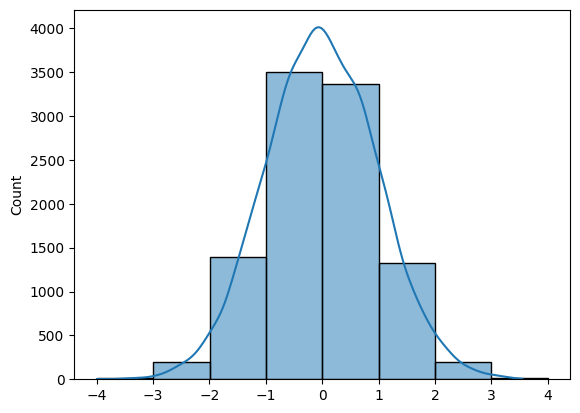

```python
x = np.random.normal(0, 1, 10000)
sns.histplot(x, kde = True, binwidth = 1);
```

The blue line is a kernal density estimate function. The KDE is an approximation for a univariate probability density function. The next plot converts the count values on the y axis to probability density values.

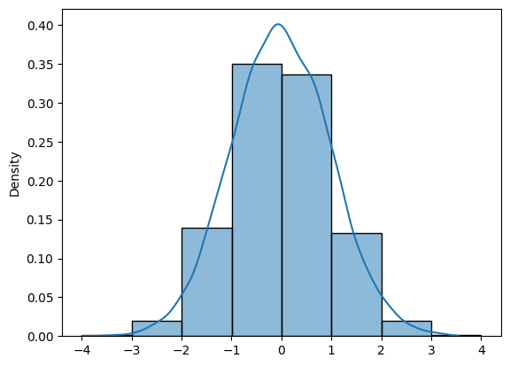

```python
sns.histplot(x, kde = True, stat='density', binwidth = 1);
```

At the interval $x=[-0.5,0.5]$, the sample proportion is roughly $\frac{4,000}{10,000}$. It is clear to see how we arrive at a probabilitity density of $0.4$ when $\Delta x=1$. In other words; the product of density $(0.4)$ and the interval of $x=1$ yiels a probability proportion of $0.4$.

The probability on an interval of $X$ is equal to the density times that interval, or the binwidth. More succinctly,

$\displaystyle {\sum_{i=1}^n} f(x_i) \Delta x$

In which for this example,

$\displaystyle {\sum_{i=1}^7} f(x) *(1) \approx 1$

where $f(x)$ is our discrete probability density.

As the binwidth approaches $0$, we find the approximation achieves more accuracy, i.e., closer to $1$.

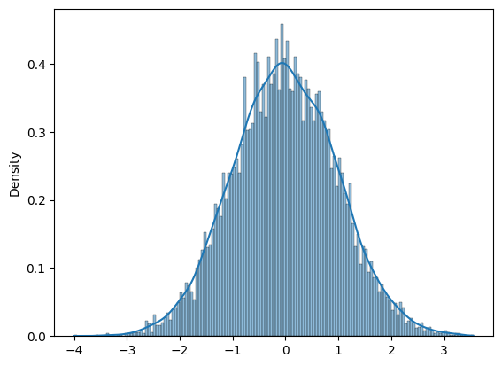

```python
sns.histplot(x, kde = True, stat='density', binwidth = .05);
```

The expected value of $X$ is defined as

$E[X] = \displaystyle {\lim_{n\rightarrow \infty}}\sum_{i=1}^n x_i f(x_i) \Delta x = \int_{a}^{b} x f(x) dx $.

The intuition behind this is that we are summing up the products of each $x$ value with their corresponding probability slice, $f(x) dx$.

To get a better understanding of expected values, we will run a simulation of 10 dice being randomly rolled, then summed over 100,000 iterations.

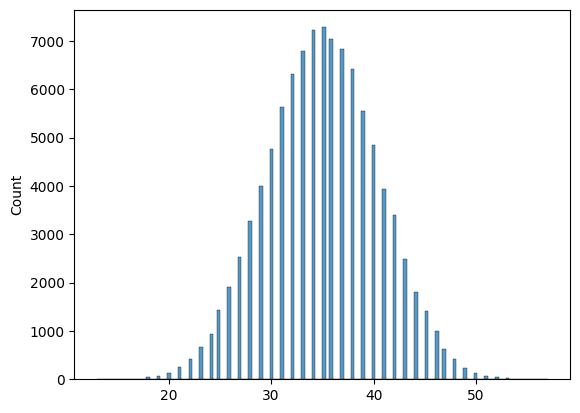

```python
rand = []
for i in range(100000):
    x = np.random.randint(1,7)
    y = np.random.randint(1,7)
    z = np.random.randint(1,7)
    h = np.random.randint(1,7)
    k = np.random.randint(1,7)
    j = np.random.randint(1,7)
    a = np.random.randint(1,7)
    b = np.random.randint(1,7)
    c = np.random.randint(1,7)
    d = np.random.randint(1,7)
    rand.append(x+y+z+h+k+j+a+b+c+d)
sns.histplot(rand);
```

The expected value of one die is equal to $3.5$. We find this by first finding the probability of each die value, which come from a uniform distribution, such that $p=\frac{1}{6}$. By summing the product of the individual probabilities of rolling each number by their numerical value, we find the expected value. We see that $E[X]=3.5$. And 10 dice lead us to a mean value of $35$ from our distribution. This provides us enough of a foundation to move on to joint distributions.

### Part II - Joint Probability Density Function, Covariance, and Correlation

Similar to a univariate PDF, A joint probability density function describes how likely it is to simultaneously observe two or more outcomes resulting from data-generating processes. Formally, we write this as $P(X \cap Y)$.

Let $X,Y \in \mathbb{R}$ be random variables. The probability density function takes the form of $f(x,y)$ in which two conditions must be satisfied:

1. $f(x,y) \geq 0$
2. $\int \int_{R} f(x,y) dx dy = 1$

The probability of observing values between $x=[a,b]$ and $y=[c,d]$ is

$P(X\in [a,b],Y \in [c,d]) =\int_{c}^{d}\int_{a}^{b}f(x,y) dx dy$.

The value of the function $f(x,y)$ represents the probability of a given $x$ and $y$ occuring within an infinitely small region.

[figure not shown]

[figure not shown]

[figure not shown]

[figure not shown]

```python
y= np.random.normal (size=10000)
df1 = pd.DataFrame({'x':x,'y':y})
sns.jointplot(x='x',y='y', data= df1, kind = 'hist', legend = True,binwidth = 4, stat='density',cbar=True);
sns.jointplot(x='x',y='y', data= df1, kind = 'hist', legend = True, binwidth = 1,stat='density',cbar=True)
sns.jointplot(x='x',y='y', data= df1, kind = 'hist', legend = True,stat='density',cbar=True)
sns.jointplot(x='x',y='y', data= df1, kind = 'kde', fill = True,stat='density',cbar=True)
```

We find that these plots follow a similar mechanism to the univariate distributions, but with another dimension added! The joint probability is simply the product of the joint density value and its corresponding, infinitely small area $dA = dx dy$. Furthermore,

$\displaystyle {\sum_{i=1}^n} f(x,y) \Delta A$.

### Expected Value of a Joint Distribution & Covariance

The expectation value of the joint distribution of random variables $x$ and $y$ can be written as

$E[g(X,Y)] = \int_{c}^{d}\int_{a}^{b} g(x,y) \cdot p(x,y) dxdy$.

The intuition carries through from above, with simply another dimension added. To help myself think about this visually, we are adding up samll neighborhoods of density times area and multiplying it by the value of $g(x,y)$ at that point. This gives us in a sense the average value of $g(x,y)$.

### Conclusion

So that's the basics in adding a second dimension to probability density functions. this can be scaled to $n$-dimensions for additional variables.